# ASSIGNMENT Exploratory Data Analysis with R Notebook

Problem1—Exploring Vegas Hotel Dataset 1)Exploring overall structure of the dataset usig str()

```r
hoteldata = read.csv("C:/Users/prabh/Desktop/LasVegasTripAdvisorReviews-Dataset (1).csv", stringsAsFactors = TRUE)
str(hoteldata)
```

```
'data.frame':   504 obs. of  20 variables:
 $ ï..User.country  : Factor w/ 48 levels "Australia","Belgium",..: 48 48 48 46 4 4 46 48 18 4 ...
 $ Nr..reviews      : int  11 119 36 14 5 31 45 2 24 12 ...
 $ Nr..hotel.reviews: int  4 21 9 7 5 8 12 1 3 7 ...
 $ Helpful.votes    : int  13 75 25 14 2 27 46 4 8 11 ...
 $ Score            : int  5 3 5 4 4 3 4 4 4 3 ...
 $ Period.of.stay   : Factor w/ 4 levels "Dec-Feb","Jun-Aug",..: 1 1 3 3 3 3 3 3 3 3 ...
 $ Traveler.type    : Factor w/ 5 levels "Business","Couples",..: 4 1 3 4 5 2 2 3 4 3 ...
 $ Pool             : Factor w/ 2 levels "NO","YES": 1 1 1 1 1 1 1 1 1 1 ...
 $ Gym              : Factor w/ 2 levels "NO","YES": 2 2 2 2 2 2 2 2 2 2 ...
 $ Tennis.court     : Factor w/ 2 levels "NO","YES": 1 1 1 1 1 1 1 1 1 1 ...
 $ Spa              : Factor w/ 2 levels "NO","YES": 1 1 1 1 1 1 1 1 1 1 ...
 $ Casino           : Factor w/ 2 levels "NO","YES": 2 2 2 2 2 2 2 2 2 2 ...
 $ Free.internet    : Factor w/ 2 levels "NO","YES": 2 2 2 2 2 2 2 2 2 2 ...
 $ Hotel.name       : Factor w/ 21 levels "Bellagio Las Vegas",..: 3 3 3 3 3 3 3 3 3 3 ...
 $ Hotel.stars      : int  3 3 3 3 3 3 3 3 3 3 ...
 $ Nr..rooms        : int  3773 3773 3773 3773 3773 3773 3773 3773 3773 3773 ...
 $ User.continent   : Factor w/ 7 levels "","Africa","Asia",..: 5 5 5 4 5 5 4 5 3 5 ...
 $ Member.years     : int  9 3 2 6 7 2 4 0 3 5 ...
 $ Review.month     : Factor w/ 13 levels "","April","August",..: 6 6 5 5 9 9 2 2 10 10 ...
 $ Review.weekday   : Factor w/ 8 levels "","Friday","Monday",..: 6 2 4 2 7 7 2 7 4 7 ...
```

2)does any of the variables have missing values? ANS - Yes, some values are missing

```r
#options(max.print = 1000000)
is.na(hoteldata)
```

```
       ï..User.country Nr..reviews Nr..hotel.reviews Helpful.votes Score
  [1,]           FALSE       FALSE             FALSE         FALSE FALSE
  [2,]           FALSE       FALSE             FALSE         FALSE FALSE
  [3,]           FALSE       FALSE             FALSE         FALSE FALSE
  [4,]           FALSE       FALSE             FALSE         FALSE FALSE
  [5,]           FALSE       FALSE             FALSE         FALSE FALSE
  [6,]           FALSE       FALSE             FALSE         FALSE FALSE
  [7,]           FALSE       FALSE             FALSE         FALSE FALSE
  [8,]           FALSE       FALSE             FALSE         FALSE FALSE
  [9,]           FALSE       FALSE             FALSE         FALSE FALSE
 [10,]           FALSE       FALSE             FALSE         FALSE FALSE
 [11,]           FALSE       FALSE             FALSE         FALSE FALSE
 [12,]           FALSE       FALSE             FALSE         FALSE FALSE
 [13,]           FALSE       FALSE             FALSE         FALSE FALSE
 [14,]           FALSE       FALSE             FALSE         FALSE FALSE
```

[output cut: 178 more lines]

```r
length(which(is.na(hoteldata)))
```

```
[1] 192
```

```r
which(is.na(hoteldata))
```

```
  [1] 7801 7802 7803 7804 7805 7806 7807 7808 7809 7810 7811 7812 7813 7814
 [15] 7815 7816 7817 7818 7819 7820 7821 7822 7823 7824 7849 7850 7851 7852
 [29] 7853 7854 7855 7856 7857 7858 7859 7860 7861 7862 7863 7864 7865 7866
 [43] 7867 7868 7869 7870 7871 7872 7873 7874 7875 7876 7877 7878 7879 7880
 [57] 7881 7882 7883 7884 7885 7886 7887 7888 7889 7890 7891 7892 7893 7894
 [71] 7895 7896 7945 7946 7947 7948 7949 7950 7951 7952 7953 7954 7955 7956
 [85] 7957 7958 7959 7960 7961 7962 7963 7964 7965 7966 7967 7968 8809 8810
 [99] 8811 8812 8813 8814 8815 8816 8817 8818 8819 8820 8821 8822 8823 8824
[113] 8825 8826 8827 8828 8829 8830 8831 8832 8857 8858 8859 8860 8861 8862
[127] 8863 8864 8865 8866 8867 8868 8869 8870 8871 8872 8873 8874 8875 8876
[141] 8877 8878 8879 8880 8881 8882 8883 8884 8885 8886 8887 8888 8889 8890
[155] 8891 8892 8893 8894 8895 8896 8897 8898 8899 8900 8901 8902 8903 8904
[169] 8953 8954 8955 8956 8957 8958 8959 8960 8961 8962 8963 8964 8965 8966
[183] 8967 8968 8969 8970 8971 8972 8973 8974 8975 8976
```

3)Histogram of score variable In the score histogram, the tallest bar is not at the center of the data, but on the right-hand side of the diagram. It includes more than 200 people who gave rating of 5.

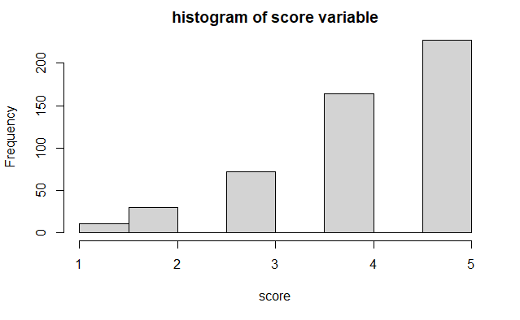

```r
hist(hoteldata$Score, main="histogram of score variable", xlab = "score")
```

4)Mode of “score” variable in the dataset Ans : mode = 5

```r
table(hoteldata$Score)
```

```
  1   2   3   4   5
 11  30  72 164 227
```

```r
x <- hoteldata$Score
temp <- table(as.vector(x))
names(temp)[temp == max(temp)]
```

```
[1] "5"
```

5)quantile function to get quantiles and “median” value of ‘score’ variable

```r
quantile(x)
```

```
  0%  25%  50%  75% 100%
   1    4    4    5    5
```

```r
summary(x)
```

```
   Min. 1st Qu.  Median    Mean 3rd Qu.    Max.
  1.000   4.000   4.000   4.123   5.000   5.000
```

```r
hoteldata$sentiment =factor(c("positive", "negative"))
myRange <- 1:length(hoteldata$Score)
for(i in myRange) {
  if (hoteldata$Score[i] > 3) {
    hoteldata$sentiment[i] <- "positive"
  } else {
    hoteldata$sentiment[i] <- "negative"
  }
}
hoteldata
```

| ï..User.country | Nr..reviews | Nr..hotel.reviews | Helpful.votes | Score | Period.of.stay | Traveler.type | Pool | Gym | Tennis.court | Spa | Casino | Free.internet | Hotel.name | Hotel.stars | Nr..rooms | User.continent | Member.years | Review.month | Review.weekday | sentiment |
| --- | --- | --- | --- | --- | --- | --- | --- | --- | --- | --- | --- | --- | --- | --- | --- | --- | --- | --- | --- | --- |
| USA | 11 | 4 | 13 | 5 | Dec-Feb | Friends | NO | YES | NO | NO | YES | YES | Circus Circus Hotel & Casino Las Vegas | 3 | 3773 | North America | 9 | January | Thursday | positive |
| USA | 119 | 21 | 75 | 3 | Dec-Feb | Business | NO | YES | NO | NO | YES | YES | Circus Circus Hotel & Casino Las Vegas | 3 | 3773 | North America | 3 | January | Friday | negative |
| USA | 36 | 9 | 25 | 5 | Mar-May | Families | NO | YES | NO | NO | YES | YES | Circus Circus Hotel & Casino Las Vegas | 3 | 3773 | North America | 2 | February | Saturday | positive |
| UK | 14 | 7 | 14 | 4 | Mar-May | Friends | NO | YES | NO | NO | YES | YES | Circus Circus Hotel & Casino Las Vegas | 3 | 3773 | Europe | 6 | February | Friday | positive |
| Canada | 5 | 5 | 2 | 4 | Mar-May | Solo | NO | YES | NO | NO | YES | YES | Circus Circus Hotel & Casino Las Vegas | 3 | 3773 | North America | 7 | March | Tuesday | positive |
| Canada | 31 | 8 | 27 | 3 | Mar-May | Couples | NO | YES | NO | NO | YES | YES | Circus Circus Hotel & Casino Las Vegas | 3 | 3773 | North America | 2 | March | Tuesday | negative |
| UK | 45 | 12 | 46 | 4 | Mar-May | Couples | NO | YES | NO | NO | YES | YES | Circus Circus Hotel & Casino Las Vegas | 3 | 3773 | Europe | 4 | April | Friday | positive |
| USA | 2 | 1 | 4 | 4 | Mar-May | Families | NO | YES | NO | NO | YES | YES | Circus Circus Hotel & Casino Las Vegas | 3 | 3773 | North America | 0 | April | Tuesday | positive |
| India | 24 | 3 | 8 | 4 | Mar-May | Friends | NO | YES | NO | NO | YES | YES | Circus Circus Hotel & Casino Las Vegas | 3 | 3773 | Asia | 3 | May | Saturday | positive |
| Canada | 12 | 7 | 11 | 3 | Mar-May | Families | NO | YES | NO | NO | YES | YES | Circus Circus Hotel & Casino Las Vegas | 3 | 3773 | North America | 5 | May | Tuesday | negative |

[output cut: 494 more lines]

```r
NA
```

```r
str(sentiment)
```

```
 Factor w/ 2 levels "negative","positive": 2 1
```

```r
summary(sentiment)
```

```
negative positive
       1        1
```

7. Pool, Free internet and hotel.stars are associated with sentiment

```r
installed.packages("gmodels")
```

```
     Package LibPath Version Priority Depends Imports LinkingTo Suggests
     Enhances License License_is_FOSS License_restricts_use OS_type Archs
     MD5sum NeedsCompilation Built
```

```r
library(gmodels)
mytable<-table(hoteldata$sentiment, hoteldata$Pool)
mytable
```

```
            NO YES
  negative  13 100
  positive  11 380
```

```r
chisq.test(mytable)
```

```
    Pearson's Chi-squared test with Yates' continuity correction

data:  mytable
X-squared = 12.748, df = 1, p-value = 0.0003565
```

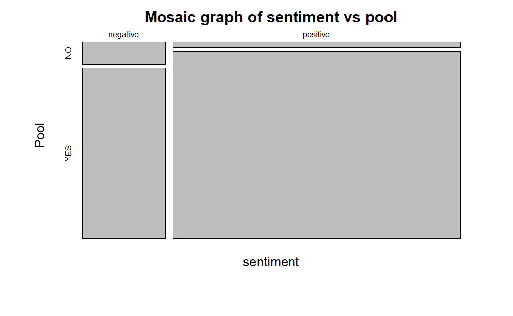

```r
mosaicplot(mytable, ylab="Pool", xlab = "sentiment", main = "Mosaic graph of sentiment vs pool")
```

```r
mytable1<-table(hoteldata$sentiment, hoteldata$Gym)
mytable1
```

```
            NO YES
  negative   6 107
  positive  18 373
```

```r
chisq.test(mytable1)
```

```
    Pearson's Chi-squared test with Yates' continuity correction

data:  mytable1
X-squared = 0.0035647, df = 1, p-value = 0.9524
```

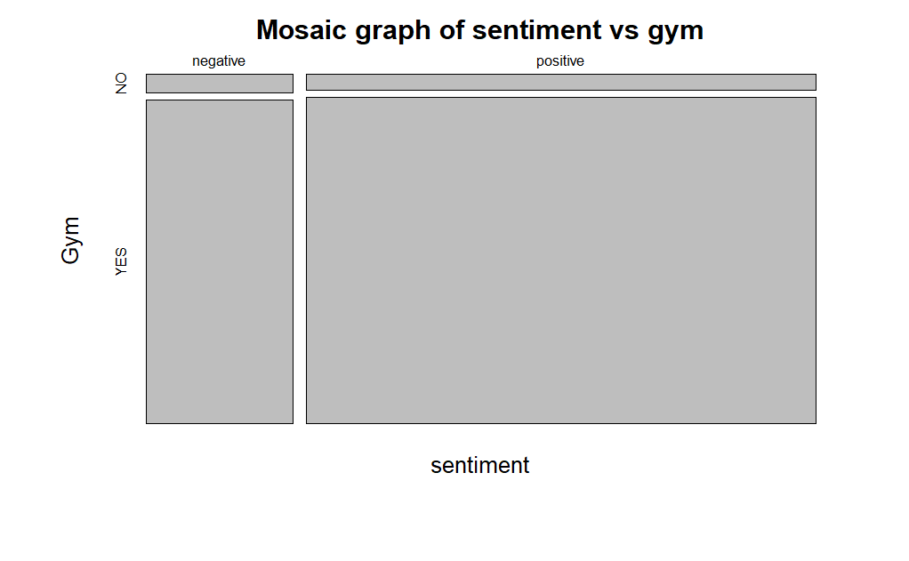

```r
mosaicplot(mytable1, ylab="Gym", xlab = "sentiment", main = "Mosaic graph of sentiment vs gym")
```

```r
mytable2<-table(hoteldata$sentiment, hoteldata$Free.internet)
mytable2
```

```
            NO YES
  negative  12 101
  positive  12 379
```

```r
chisq.test(mytable2)
```

```
    Pearson's Chi-squared test with Yates' continuity correction

data:  mytable2
X-squared = 9.4178, df = 1, p-value = 0.002149
```

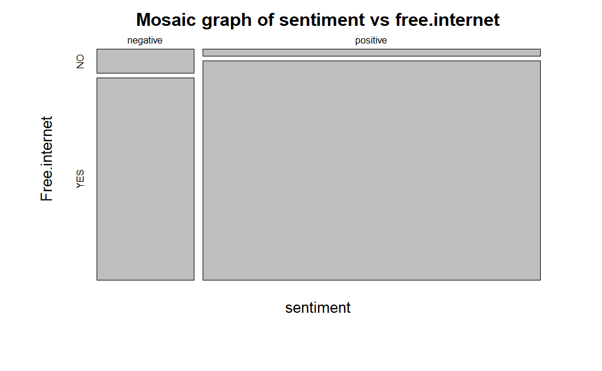

```r
mosaicplot(mytable2, ylab="Free.internet", xlab = "sentiment", main = "Mosaic graph of sentiment vs free.internet")
```

```r
mytable3<-table(hoteldata$sentiment, hoteldata$Period.of.stay)
mytable3
```

```
           Dec-Feb Jun-Aug Mar-May Sep-Nov
  negative      24      24      33      32
  positive     100     102      95      94
```

```r
chisq.test(mytable3)
```

```
    Pearson's Chi-squared test

data:  mytable3
X-squared = 2.967, df = 3, p-value = 0.3967
```

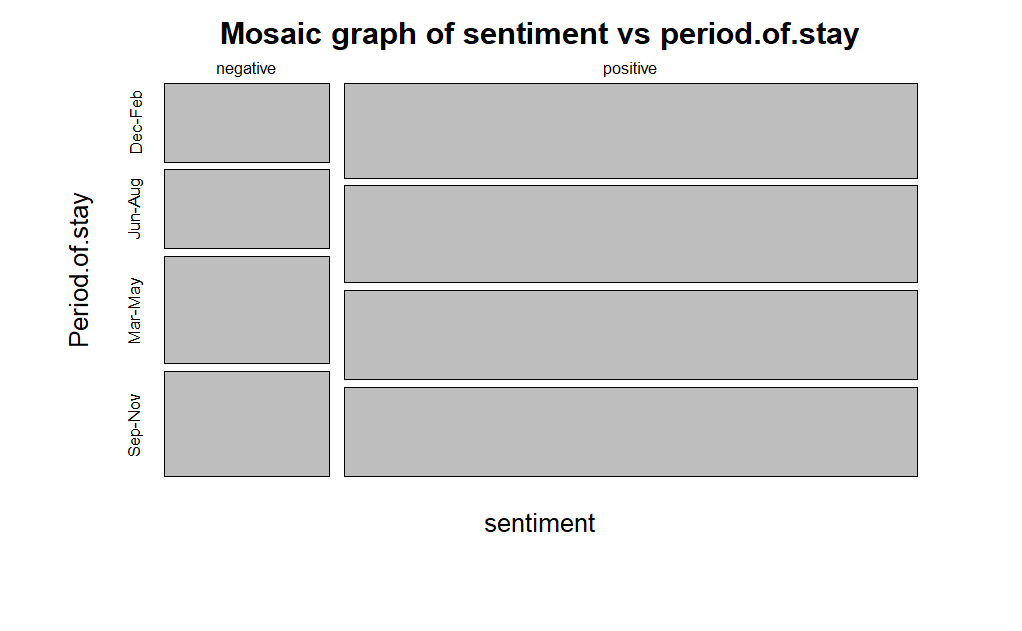

```r
mosaicplot(mytable3, ylab="Period.of.stay", xlab = "sentiment", main = "Mosaic graph of sentiment vs period.of.stay")
```

```r
mytable4<-table(hoteldata$sentiment, hoteldata$Traveler.type)
mytable4
```

```
           Business Couples Families Friends Solo
  negative       21      39       33      14    6
  positive       53     175       77      68   18
```

```r
chisq.test(mytable4)
```

```
    Pearson's Chi-squared test

data:  mytable4
X-squared = 8.7495, df = 4, p-value = 0.06768
```

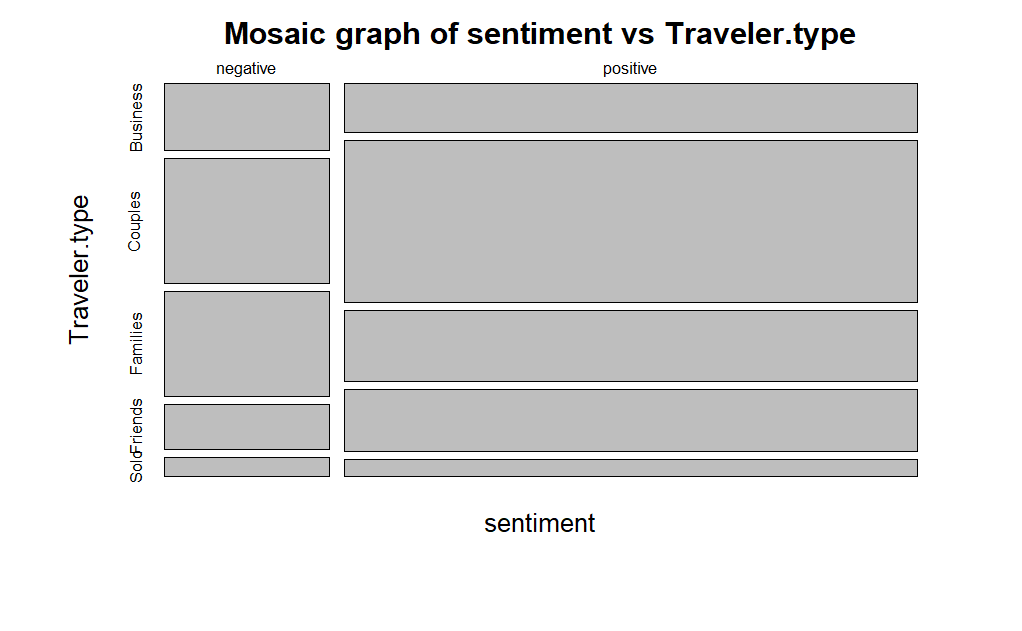

```r
mosaicplot(mytable4, ylab="Traveler.type", xlab = "sentiment", main = "Mosaic graph of sentiment vs Traveler.type")
```

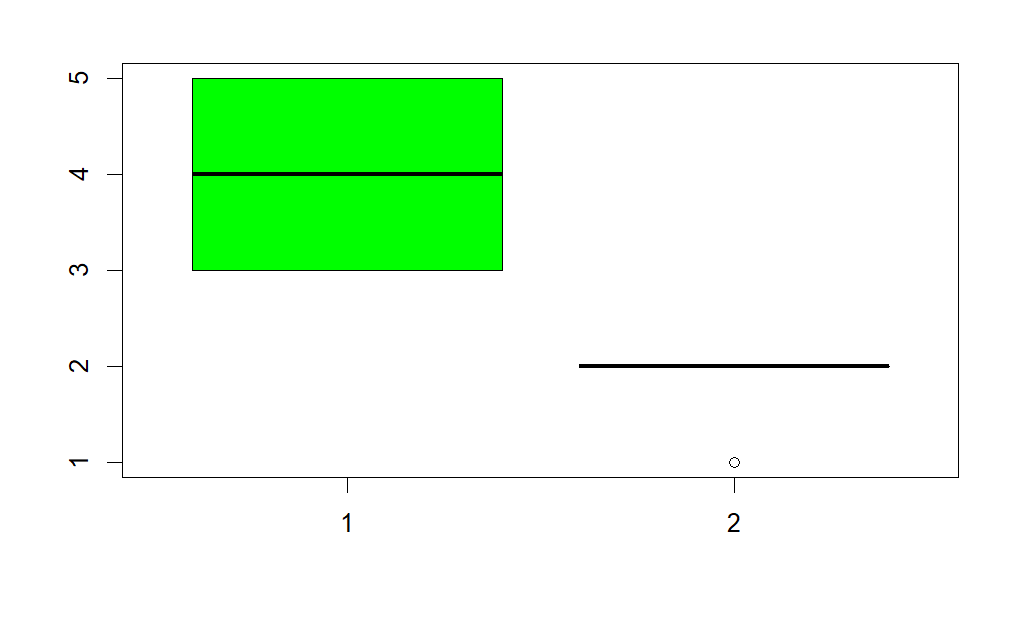

```r
#mytable5<-table(hoteldata$sentiment, hoteldata$Hotel.stars)
#mytable5
hstars = as.factor(hoteldata$Hotel.stars)
boxplot(hoteldata$Hotel.stars, hoteldata$sentiment, col="green")
```

```r
t.test(hoteldata$Hotel.stars~hoteldata$sentiment, alternative="two.sided")
```

```
    Welch Two Sample t-test

data:  hoteldata$Hotel.stars by hoteldata$sentiment
t = -3.5557, df = 197.45, p-value = 0.0004719
alternative hypothesis: true difference in means between group negative and group positive is not equal to 0
95 percent confidence interval:
 -0.4678322 -0.1340282
sample estimates:
mean in group negative mean in group positive
              3.814159               4.115090
```

```r
#chisq.test(mytable5)
#mosaicplot(mytable5, ylab="Hotel.stars", xlab = "sentiment", main = "Mosaic graph of sentiment vs hotel.stars")
```

PROBLEM 2:Exploring California Housing Dataset 1)structure of the dataset There are 9 numerical variables and 1 categorical variable

```r
housingdata = read.csv("C:/Users/prabh/housing-1.csv", stringsAsFactors = FALSE)
str(housingdata)
```

```
'data.frame':   20640 obs. of  10 variables:
 $ longitude         : num  -122 -122 -122 -122 -122 ...
 $ latitude          : num  37.9 37.9 37.9 37.9 37.9 ...
 $ housing_median_age: num  41 21 52 52 52 52 52 52 42 52 ...
 $ total_rooms       : num  880 7099 1467 1274 1627 ...
 $ total_bedrooms    : num  129 1106 190 235 280 ...
 $ population        : num  322 2401 496 558 565 ...
 $ households        : num  126 1138 177 219 259 ...
 $ median_income     : num  8.33 8.3 7.26 5.64 3.85 ...
 $ median_house_value: num  452600 358500 352100 341300 342200 ...
 $ ocean_proximity   : chr  "NEAR BAY" "NEAR BAY" "NEAR BAY" "NEAR BAY" ...
```

2)summary of dataset and does any of the variables has missing values? yes, missing values are there

```r
summary(housingdata)
```

[output not shown]

```r
which(is.na(housingdata))
```

```
  [1]  82851  82902  83099  83124  83257  83299  83658  83911  84017  84054
 [11]  84167  84589  84676  84862  84884  84895  84912  84973  84981  85139
 [21]  85169  85208  85387  85585  85889  85915  85937  86043  86046  86090
 [31]  86282  86339  86473  86482  86519  86604  86607  86747  86840  86870
 [41]  86952  87008  87057  87152  87161  87190  87228  87252  87299  87304
 [51]  87305  87328  87413  87620  87777  87783  87797  88215  88226  88239
 [61]  88284  88312  88551  88613  88629  88781  88802  88814  88859  88982
 [71]  89102  89151  89375  89396  89523  89658  89674  89729  89752  89789
 [81]  89877  89891  90108  90215  90229  90324  90367  90898  90944  91091
 [91]  91476  91710  92132  92181  92183  92375  92406  92438  92503  92531
[101]  92594  92777  92797  92946  92950  92989  93056  93322  93446  93476
[111]  93657  93872  93912  94002  94010  94073  94302  94662  94975  95131
[121]  95370  95576  95630  95872  95893  95897  96158  96217  96267  96486
[131]  96493  96494  96576  96713  96734  96868  96892  96947  97023  97082
[141]  97202  97491  97531  97547  97591  97621  97679  97698  97958  98040
[151]  98168  98224  98451  98536  98586  98599  98665  98666  98891  99318
[161]  99440  99441  99446  99602  99759  99763 100200 100386 100401 100484
[171] 100489 100534 100738 100807 100822 100893 100907 101027 101347 101434
[181] 101475 101621 101632 101683 101711 101813 101893 101952 101963 102046
[191] 102120 102168 102199 102327 102379 102394 102451 102493 102520 102607
[201] 102630 102686 102828 102829 102933 103021 103045
```

```r
length(which(is.na(housingdata)))
```

```
[1] 207
```

3)percentage of rows having missing values in one or more variables

```r
j1=complete.cases(housingdata)
table_q = table(j1)
prop.table(table_q)
```

```
j1
     FALSE       TRUE
0.01002907 0.98997093
```

```r
sum(!j1)
```

```
[1] 207
```

4)Removing the rows with missing values

```r
na.omit(housingdata)
```

[output not shown]

[output cut: 990 more lines]

5)Histogram of the median_house_value histogram is positively skewed

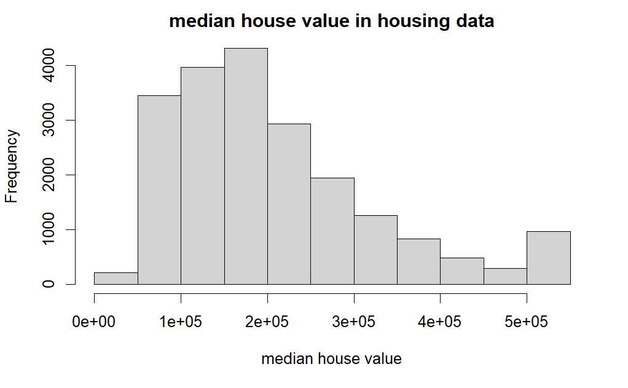

```r
hist(housingdata$median_house_value, main="median house value in housing data", xlab="median house value")
```

boxplot of median_house_value

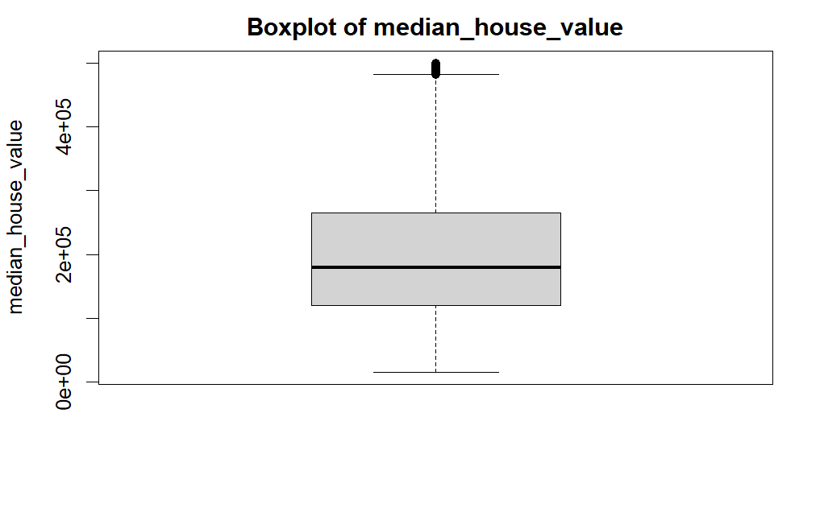

```r
boxplot(housingdata$median_house_value, main="Boxplot of median_house_value", ylab = "median_house_value")
```

5)answer: median_house_value sample is Positively skewed

6)Q-Q plot to examine if the distribution of median_house_value is approximately normal

```r
qqnorm(housingdata$median_house_value)
```

[output not shown]

```r
iqr123 <-IQR(housingdata$median_house_value)
iqr123
summary(housingdata$median_house_value)
```

[output not shown]

```r
options(max.print = 100000)
left <- 119600-1.5*iqr123
right<- 264725+1.5*iqr123
left
right
x<-housingdata$median_house_value
x[x<left | x>right]
length(which(x<left | x>right))
```

[output not shown]

8)Does any of the numerical attributes have a positive/negative linear correlation with median_house_value

```r
numeric_attributes=housingdata[,c("longitude", "latitude", "housing_median_age", "total_rooms", "total_bedrooms", "population", "households", "median_income", "median_house_value")]
cor(numeric_attributes)
```

[output not shown]

```r
plot(numeric_attributes)
```

[output not shown]

9)mean of meadian_house_valueacross different levels of ocean_proximity

```r
boxplot(housingdata$median_house_value~housingdata$ocean_proximity)
y1=table(housingdata$median_house_value, housingdata$ocean_proximity)
t.test(y1)
```

[output not shown]

10)ifelse function to create a new factor variable “Is_Inland” which takes the value “Yes” if the ocean_proximity is “Inland” and No” otherwise.

```r
myRange2 <- 1:length(housingdata$ocean_proximity)
for(i in myRange2) {
  if (housingdata$ocean_proximity[i] == "INLAND") {
    housingdata$Is_Inland[i] <- "Yes"
  } else {
    housingdata$Is_Inland[i] <- "No"
  }
}
housingdata
```

11)side by side box plot to visualize the relationship between “Is_Inland” and “median_house_value”. Is there a significant difference between the means of median_house_value for Inland vs not Inland houses

```r
median_house_value1 = factor(housingdata$median_house_value)
is_inland1 = factor(housingdata$Is_Inland)
boxplot(median_house_value1~is_inland1)
str(housingdata)
```

[output not shown]

```r
t.test(housingdata$median_house_value~housingdata$Is_Inland, alternative = "two.sided")
```

[output not shown]

Problem3- Exploring the Heart Disease Dataset 1)opening the files and examining the data in them

```r
pcd <-read.csv("C:/Users/prabh/processed.cleveland.data.csv", na.string="?", stringsAsFactors = TRUE)
str(pcd)
```

[output not shown]

```r
phd <- read.csv("C:/Users/prabh/processed.hungarian.data.csv", na.string="?", stringsAsFactors = TRUE)
str(phd)
```

[output not shown]

```r
psd <- read.csv("C:/Users/prabh/processed.switzerland.data.csv", na.string="?", stringsAsFactors = TRUE)
str(psd)
```

[output not shown]

```r
pvd <- read.csv("C:/Users/prabh/processed.va.data.csv", na.string="?", stringsAsFactors = TRUE)
str(pvd)
```

[output not shown]

2)Using rbind function to combine the four dataframes into one dataframe and manually setting the column names using colnames function

installing “plyr” package for rbind function

```r
install.packages("plyr")
library(plyr)
```

```r
allinone <- rbind.fill(pcd,phd,psd,pvd)
colnames(allinone) <- c("age","sex","cp","trestbps","chol","fbs","restecg","thalach","exang","oldpeak","slope","ca","thal","num")
allinone
```

3)structure of dataframe

```r
str(allinone)
```

[output not shown]

```r
percentage = mean(is.na(allinone)) * 100
percentage
```

[output not shown]

4)categorical variables are converted into factor variables

```r
allinone$sex = factor(allinone$sex)
allinone$restecg = factor(allinone$restecg)
allinone$exang = factor(allinone$exang)
allinone$thal = factor(allinone$thal)
str(allinone)
```

5)median and mode of age attribute

```r
summary(allinone$age)
temp <- table(as.vector(allinone$age))
names(temp)[temp == max(temp)]
```

[output not shown]

```r
plot(allinone$sex)
```

[output not shown]

```r
rangeofnum<- 1:length(allinone$num)
for(i in rangeofnum){
if(allinone$num[i] == 0){
allinone$diagnosis[i] = "NO"
}else {
allinone$diagnosis[i] = "YES"
}
}
allinone$diagnosis <- factor(allinone$diagnosis)
allinone$diagnosis
str(allinone)
allinone
```

```r
str(allinone$diagnosis)
```

```r
allinone
```

```r
#age VS diagnosis
boxplot(allinone$age~allinone$diagnosis)
t.test(age~diagnosis, data= allinone)


#sex VS diagnosis
table_a <- table(allinone$diagnosis,allinone$sex)
table_a
mosaicplot(table_a, ylab = "sex", xlab = "diagnosis", main = "Mosaic plot of sex vs diagnosis", shade = TRUE)
chisq.test(table_a)


#cp VS diagnosis
table_b <- table(allinone$diagnosis,allinone$cp)
table_b
mosaicplot(table_b, ylab = "cp", xlab = "diagnosis", main = "Mosaic plot of cp  vs diagnosis", shade = TRUE)
chisq.test(table_b)

#trestbps VS diagnosis
boxplot(allinone$trestbps~allinone$diagnosis)
t.test(allinone$diagnosis~allinone$trestbps, alternative = "two.sided")

#chol VS diagnosis
boxplot(allinone$chol~allinone$diagnosis)
t.test(allinone$diagnosis~allinone$chol, alternative = "two.sided")

#fbs VS diagnosis
boxplot(allinone$fbs~allinone$diagnosis)
t.test(allinone$diagnosis~allinone$fbs, alternative = "two.sided")

#restecg VS diagnosis
table_c <- table(allinone$restecg,allinone$diagnosis)
table_c
mosaicplot(table_c, ylab = "diagnosis", xlab = "restecg", main = "Mosaic plot of restecg vs diagnosis", shade = TRUE)
chisq.test(table_c)


#thalach VS diagnosis
boxplot(allinone$thalach~allinone$diagnosis)
t.test(allinone$diagnosis~allinone$thalach, alternative = "two.sided")


#exang VS diagnosis
table_d <- table(allinone$diagnosis, allinone$exang)
table_d
mosaicplot(table_d, ylab = "exang", xlab = "diagnosis", main = "Mosaic plot of exang vs diagnosis", shade = TRUE)
chisq.test(table_d)

#oldpeak VS diagnosis
boxplot(allinone$oldpeak~allinone$diagnosis)
t.test(allinone$diagnosis~allinone$oldpeak, alternative = "two.sided")

#slope VS diagnosis
boxplot(allinone$slope~allinone$diagnosis)
t.test(allinone$diagnosis~allinone$slope, alternative = "two.sided")

#diagnosis VS ca
table_e <- table(allinone$diagnosis,allinone$ca)
table_e
mosaicplot(table_e, ylab = "ca", xlab = "diagnosis", main = "Mosaic plot of diagnosis vs ca", shade = TRUE)
chisq.test(table_e)
#diagnosis VS thal
table_f <- table(allinone$diagnosis,allinone$thal)
table_f
mosaicplot(table_e, ylab = "thal", xlab = "diagnosis", main = "Mosaic plot of diagnosis vs thal", shade = TRUE)
chisq.test(table_e)
```

[output not shown]